# Diversification & SSE Models

Let’s study the diversification proces using the R package `diversitree` written by Rich FitzJohn.

```r
library(diversitree)
library(treeplyr)
library(TreeSim)
```

# Birth-Death Models

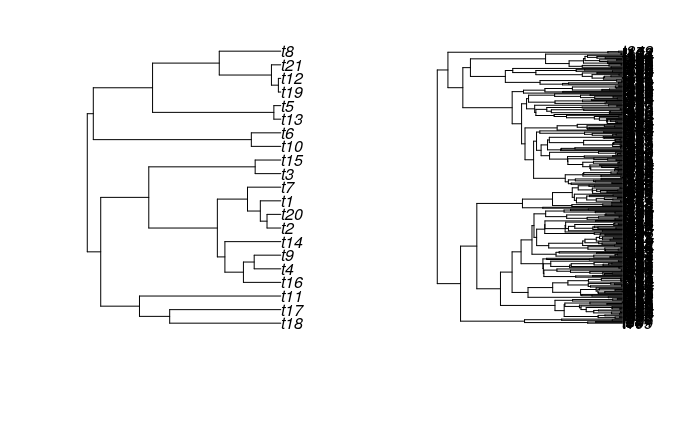

```r
set.seed(1)
tree1 <- sim.bd.age(age=100, numbsim=1, lambda=0.03, mu=0)[[1]]
tree2 <- sim.bd.age(age=100, numbsim=1, lambda=0.06, mu=0)[[1]]
par(mfrow=c(1,2))
plot(tree1)
plot(tree2)
```

`Diversitree` works by first making the likelihood functions for a particular dataset. For example, for the simulated trees above, we can define the likelihood functions below using the function `make.bd`, which makes birth-death model with two parameters. What are the parameters?

```r
model.tree1 <- make.bd(tree1)
model.tree2 <- make.bd(tree2)
model.tree1(c(0.1,0))
```

```
[1] -65.32872
```

```r
model.tree2(c(0.1, 0))
```

```
[1] 266.2724
```

Now we can optimize using the function `find.mle`, providing it with our starting parameter values.

```r
mle_tree1 <- find.mle(model.tree1, c(0.1, 0))
```

```
Convergence problems in find.mle: code = 3 (see ?nlm for details)
```

```r
mle_tree2 <- find.mle(model.tree2, c(0.1, 0))
mle_tree1
```

```
$par
    lambda         mu
0.03485649 0.01045494

$lnLik
[1] -43.37943

$counts
[1] 12

$code
[1] 3

$gradient
[1] -0.0010182008  0.0004316936

$method
[1] "nlm"

$func.class
[1] "bd"       "dtlik"    "function"

attr(,"func")
Constant rate birth-death likelihood function:
  * Parameter vector takes 2 elements:
     - lambda, mu
  * Function takes arguments (with defaults)
     - pars: Parameter vector
     - condition.surv [TRUE]: Condition likelihood on survial?
     - intermediates [FALSE]: Also return intermediate values?
  * Phylogeny with 21 tips and 20 nodes
     - Taxa: t11, t18, t17, t8, t14, t16, t7, t10, t6, t4, t9, t3, t15, t1, t2, t20, t21, t13, t5, t19, t12
  * Reference:
     - Nee et al. (1994) doi:10.1098/rstb.1994.0068
R definition:
function (pars, condition.surv = TRUE, intermediates = FALSE)
attr(,"class")
[1] "fit.mle.bd" "fit.mle"
```

```r
mle_tree2
```

```
$par
      lambda           mu
5.939302e-02 1.268648e-07

$lnLik
[1] 324.6657

$counts
[1] 23

$code
[1] 2

$gradient
[1] 115.79199 -38.36836

$method
[1] "nlm"

$func.class
[1] "bd"       "dtlik"    "function"

attr(,"func")
Constant rate birth-death likelihood function:
  * Parameter vector takes 2 elements:
     - lambda, mu
  * Function takes arguments (with defaults)
     - pars: Parameter vector
     - condition.surv [TRUE]: Condition likelihood on survial?
     - intermediates [FALSE]: Also return intermediate values?
  * Phylogeny with 332 tips and 331 nodes
     - Taxa: t162, t126, t19, t296, t263, t158, t11, t167, t121, t332, t129, t7, t168, t52, t66, t310, t306, t240, ...
  * Reference:
     - Nee et al. (1994) doi:10.1098/rstb.1994.0068
R definition:
function (pars, condition.surv = TRUE, intermediates = FALSE)
attr(,"class")
[1] "fit.mle.bd" "fit.mle"
```

Note that we fit a pure birth tree and fit a birth-death model. We may wish to *constrain* parameters to test particular hypotheses. For example, let’s constrain extinction rate to 0 and fit a pure-birth tree.

```r
pb_tree1 <- constrain(model.tree1, mu ~ 0)
pb_tree2 <- constrain(model.tree2, mu ~ 0)
find.mle(pb_tree1, c(0.1)) #Notice we only have 1 free parameter now
```

```
$par
    lambda
0.02972699

$lnLik
[1] -43.46275

$counts
[1] 10

$code
[1] 1

$gradient
[1] -7.287326e-07

$method
[1] "nlm"

$par.full
    lambda         mu
0.02972699 0.00000000

$func.class
[1] "constrained" "bd"          "dtlik"       "function"

attr(,"func")
Constant rate birth-death likelihood function:
  * Parameter vector takes 1 elements:
     - lambda
  * Function constrained (original took 2 elements):
     - mu ~ 0
  * Function takes arguments (with defaults)
     - pars: Parameter vector
     - ...: Additional arguments to underlying function
     - pars.only [FALSE]: Return full parameter vector?
  * Phylogeny with 21 tips and 20 nodes
     - Taxa: t11, t18, t17, t8, t14, t16, t7, t10, t6, t4, t9, t3, t15, t1, t2, t20, t21, t13, ...
  * Reference:
     - Nee et al. (1994) doi:10.1098/rstb.1994.0068
R definition:
function (pars, ..., pars.only = FALSE)
attr(,"class")
[1] "fit.mle.bd" "fit.mle"
```

```r
find.mle(pb_tree2, c(0.1))
```

```
$par
    lambda
0.05818101

$lnLik
[1] 324.7363

$counts
[1] 7

$code
[1] 1

$gradient
[1] 3.06045e-06

$method
[1] "nlm"

$par.full
    lambda         mu
0.05818101 0.00000000

$func.class
[1] "constrained" "bd"          "dtlik"       "function"

attr(,"func")
Constant rate birth-death likelihood function:
  * Parameter vector takes 1 elements:
     - lambda
  * Function constrained (original took 2 elements):
     - mu ~ 0
  * Function takes arguments (with defaults)
     - pars: Parameter vector
     - ...: Additional arguments to underlying function
     - pars.only [FALSE]: Return full parameter vector?
  * Phylogeny with 332 tips and 331 nodes
     - Taxa: t162, t126, t19, t296, t263, t158, t11, t167, t121, t332, t129, t7, t168, t52, t66, ...
  * Reference:
     - Nee et al. (1994) doi:10.1098/rstb.1994.0068
R definition:
function (pars, ..., pars.only = FALSE)
attr(,"class")
[1] "fit.mle.bd" "fit.mle"
```

We can also feed this likelihood function to a Bayesian analysis and get an estimate of the diversification rate uncertainty.

```r
mcmc_tree1 <- mcmc(model.tree1, c(0.1,0), w=0.1, nsteps=5000, print.every=100)
```

```
100: {0.0369, 0.0098} -> -43.42734
200: {0.0637, 0.0507} -> -44.33919
300: {0.0583, 0.0607} -> -45.10779
400: {0.0492, 0.0053} -> -45.53507
500: {0.0673, 0.0423} -> -44.89027
600: {0.0571, 0.0602} -> -45.17245
700: {0.0779, 0.0736} -> -45.25228
800: {0.0376, 0.0391} -> -45.33399
900: {0.0648, 0.0638} -> -44.92830
1000: {0.0658, 0.0581} -> -44.56059
1100: {0.0317, 0.0155} -> -43.72124
1200: {0.0495, 0.0237} -> -43.85422
1300: {0.0419, 0.0076} -> -43.97824
1400: {0.0644, 0.0489} -> -44.36770
1500: {0.0303, 0.0153} -> -43.88305
```

[output cut: 35 more lines]

```r
mcmc_tree2 <- mcmc(model.tree2, c(0.1,0), w=0.1, nsteps=5000, print.every=100)
```

```
100: {0.0530, 0.0081} -> 319.90969
200: {0.0805, 0.0322} -> 319.77682
300: {0.0613, 0.0094} -> 324.06691
400: {0.0593, 0.0012} -> 324.69351
500: {0.0605, 0.0134} -> 322.77423
600: {0.0604, 0.0106} -> 323.60211
700: {0.0580, 0.0008} -> 324.70089
800: {0.0675, 0.0196} -> 322.87032
900: {0.0703, 0.0231} -> 322.32791
1000: {0.0670, 0.0068} -> 323.18404
1100: {0.0662, 0.0198} -> 322.61997
1200: {0.0621, 0.0121} -> 323.68301
1300: {0.0622, 0.0018} -> 324.23147
1400: {0.0548, 0.0056} -> 322.54454
1500: {0.0587, 0.0028} -> 324.61124
```

[output cut: 35 more lines]

```r
cols <- c("red", "green")
par(mfrow=c(3,1), mar=c(5,4,0,1))
profiles.plot(cbind("tree1_lambda"=mcmc_tree1[,'lambda'], "tree2_lambda"=mcmc_tree2[,'lambda']), col.line=cols, legend="topright")
abline(v=c(0.03, 0.06), col=cols, lwd=2, lty=2)
```

```r
profiles.plot(cbind("tree1_mu"=mcmc_tree1[,'mu'], "tree2_mu"=mcmc_tree2[,'mu']), col.line=cols, legend="topright")
profiles.plot(cbind("tree1_dr"=mcmc_tree1[,'lambda']-mcmc_tree1[,'mu'], "tree2_dr"=mcmc_tree2[,'lambda'])-mcmc_tree2[,'mu'], col.line=cols, legend="topright")
```

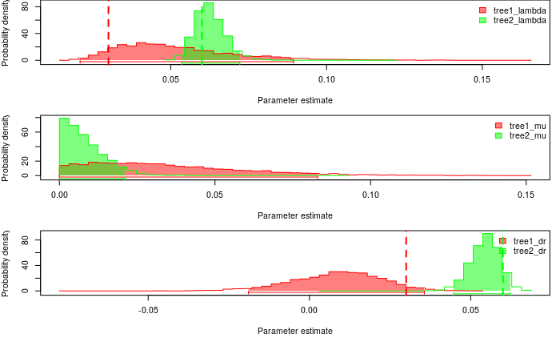

```r
abline(v=c(0.03, 0.06), col=cols, lwd=2, lty=2)
```

# Trait models

We can use the same machinery to fit character state evolution models (CTMC) models. First let’s simulate some data with and without trait dependent diversification.

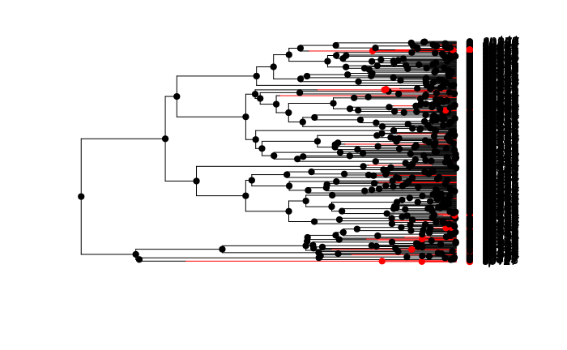

```r
simPars <- c(0.5, 0.2, 0.05, 0.05, 0.05, 0.05)
set.seed(10)
simBisseData <- tree.bisse(simPars, max.t = 14, x0 = 0)
hist <- history.from.sim.discrete(simBisseData, 0:1)
plot(hist, simBisseData)
```

```r
nbModel <- make.bisse(simBisseData, simBisseData$tip.state)
p <- starting.point.bisse(simBisseData)
nbModelMLFit <- find.mle(nbModel, p)
rbind(real = simPars, estimated = round(coef(nbModelMLFit), 2))
```

[output not shown]

```r
cnbModel <- constrain(nbModel, lambda1 ~ lambda0)
cnbModel <- constrain(cnbModel, mu1 ~ mu0)
cnbModelMLFit <- find.mle(cnbModel, p[c(-1, -3)])
```

```r
anova(nbModelMLFit, constrained = cnbModelMLFit)
```

```
            Df   lnLik    AIC  ChiSq Pr(>|Chi|)
full         6 -762.82 1537.6
constrained  4 -773.00 1554.0 20.359  3.794e-05 ***
---
Signif. codes:  0 ‘***’ 0.001 ‘**’ 0.01 ‘*’ 0.05 ‘.’ 0.1 ‘ ’ 1
```

# Challenge: How many times have geckos evolved adhesive toepads?

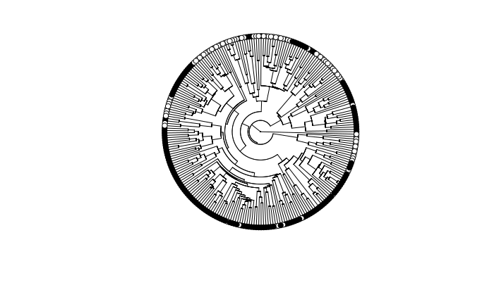

```r
dat <- read.csv("./Gecko_toes.csv")
tree <- read.nexus("./Gecko_RAxML_tree.nex")
td <- make.treedata(tree, dat)
td$phy <- chronopl(td$phy, 0)##Really crappy way of making ultrametric
plot(td$phy, show.tip.label=FALSE, type="fan")
tiplabels(pch=21, bg=td[['state']])
```

Tasks: 1. Fit the bisse model to these data and estimate the parameters under Maximum Likelihood

2. Fit a constrained model with equal speciation and extinction rates between the two states (state-independent model). Estimate parameters and fit to the data.
3. Compare the BiSSE model to the constrained model and report the best-fitting model (if equivalent, then “best model” is the model with fewest parameters)
4. Test for a single origin of toepads in the geckos by constraining the best model from above (either the BiSSE model or the state-independent model) to have the relevant transition parameter set to 0. Compare this constrained model to the original model and report the best fitting model.
5. Use the best-fitting model to reconstruct ancestral states using `asr.marginal`.

```r
#asr <- asr.marginal(cbisseModel, cbisseFit$par)
#plot(td$phy, type="fan", show.tip.label=FALSE)
#tiplabels(pch=21, bg=td[['state']])
#nodelabels(pie=t(asr), piecol=0:1, cex=0.3)
```